# Assignment 7 - Repeated measure

Author

Ruben Vinueza

# 1 Introduction

This assignment will ask you to conduct a repeated measure analysis.

For that, you will first need to watch (and code along with) the following repeated measure video:

- repeated measure lecture: https://youtu.be/-ANqcQhB–A?si=7YeeYqDgcLsj5erW&t=4268 (starts at 01:11:08, watch till the end, about 50 min)
- repeated measure lab part 1: https://youtu.be/GY2e-9M5bFM?si=TIw5F4EF2m9Dx5uK (watch full video, ~1h 50 min)
- repeated measure lab part 2: https://youtu.be/F3vg89ymLeM?si=Zv-RPIdS8mig4EMb (watch full video, ~2h)
- The partial script for the video above is in our GitHub repository, 04-classcode, **03-11_repeatedmeasure_partial.qmd**.
- The data set for this exercise is in oir GitHub repository, 03-classcode, **wheat_nk_balkh_rm.csv**.

**AFTER watching the video and developing the code in class**, then start working on this HW assignment.

# 2 Instructions

- Create on your GitHub a repo named `06_rm`.
- Clone it to your computer, create the necessary subfolders.
- Move the script **03-11_repeatedmeasure_partial.qmd** into the `code` subfolder.
- Move this script into the `code` subfolder
- Move the **wheat_nk_balkh_rm.csv** data set into the `data` subfolder
- On this script, fill your name under the `title` section of the YAML

# 3 Goal of this assignment

The goal is this assignment is for you to **learn about and conduct a full repeated measure analysis**.

Once you finish coding along with the videos, answer the following questions.

# 4 Questions

In class, we decided to use AIC as the metric to select the best model, and this determined the best model to be the one with a general error correlation matrix structure. If we had used BIC as the metric, then the model selected would have been the default model. Here, you are asked to use BIC and thus select the default model as the best, and perform all the steps after model selection. You may copy and paste the class script, and adapt the copied version to implement these changes.

# 5 Setup and wrangling

```r
#install.packages("nlme")
library(tidyverse) # for data wrangling and plotting
library(car) # for Anova function
library(lme4)
library(broom) # for model residuals extraction
library(emmeans) # for model mean extraction
library(multcomp) # for pairwise comparison letter display
library(nlme) # for repeated measure correlation structures
```

Reading data and doing some light wrangling.

```r
rm_rcbd_df <- read_csv("../data/wheat_nk_balkh_rm.csv") %>%
  mutate(across(trt:splot, ~factor(.))) %>%
  mutate(fdap = factor(dap))

rm_rcbd_df
```

```
# A tibble: 144 × 10
   trt   block nrate_kgha krate_kgha trtname wplot splot yield_kgha   dap fdap
   <fct> <fct> <fct>      <fct>      <fct>   <fct> <fct>      <dbl> <dbl> <fct>
 1 1     1     0          0          0+0     101   101-1       5488   120 120
 2 1     1     0          0          0+0     101   101-1       5898   130 130
 3 1     1     0          0          0+0     101   101-1       6133   140 140
 4 1     1     0          0          0+0     101   101-1       6151   150 150
 5 2     1     0          30         0+30    102   102-1       4448   120 120
 6 2     1     0          30         0+30    102   102-1       4842   130 130
 7 2     1     0          30         0+30    102   102-1       5057   140 140
 8 2     1     0          30         0+30    102   102-1       5094   150 150
 9 3     1     0          60         0+60    103   103-1       7445   120 120
10 3     1     0          60         0+60    103   103-1       7901   130 130
# ℹ 134 more rows
```

# 6 EDA

```r
summary(rm_rcbd_df)
```

```
      trt     block  nrate_kgha krate_kgha    trtname       wplot
 1      :16   1:36   0  :48     0 :48      0+0    :16   101    :12
 2      :16   2:36   100:48     30:48      0+30   :16   102    :12
 3      :16   3:36   200:48     60:48      0+60   :16   103    :12
 4      :16   4:36                         100+0  :16   201    :12
 5      :16                                100+30 :16   202    :12
 6      :16                                100+60 :16   203    :12
 (Other):48                                (Other):48   (Other):72
     splot       yield_kgha        dap         fdap
 101-1  :  4   Min.   :2795   Min.   :120.0   120:36
 101-2  :  4   1st Qu.:4788   1st Qu.:127.5   130:36
 101-3  :  4   Median :5280   Median :135.0   140:36
 102-1  :  4   Mean   :5233   Mean   :135.0   150:36
 102-2  :  4   3rd Qu.:5782   3rd Qu.:142.5
 102-3  :  4   Max.   :8121   Max.   :150.0
 (Other):120
```

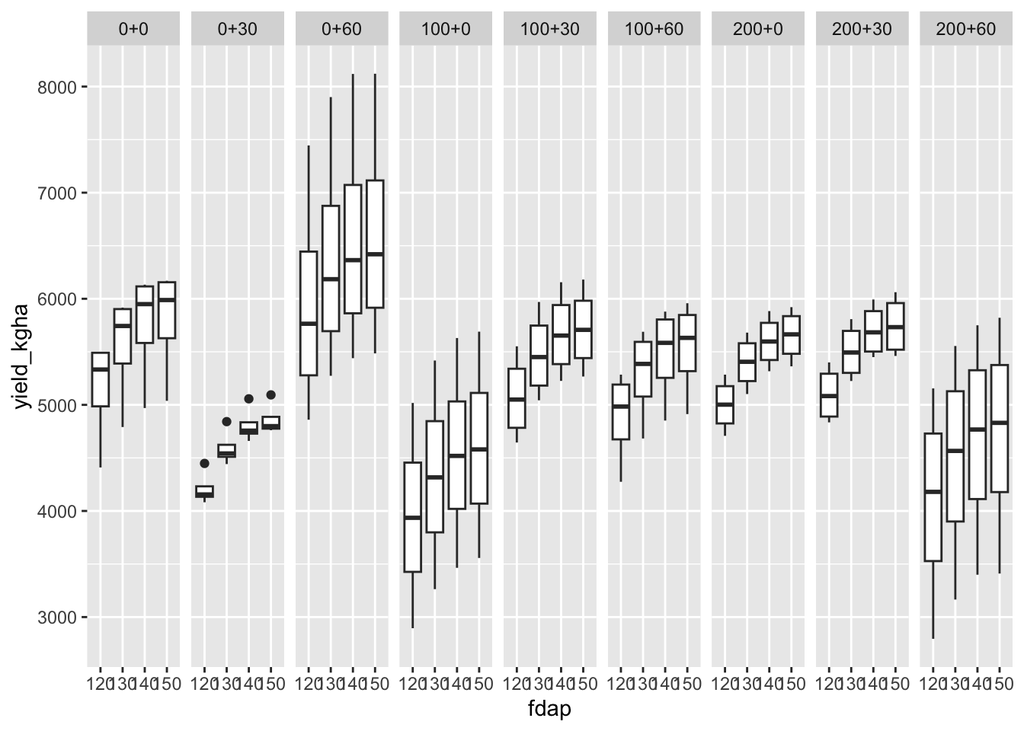

```r
ggplot(rm_rcbd_df, aes(x = fdap,
                       y = yield_kgha)) +
  geom_boxplot() +
  facet_grid(.~trtname)
```

# 7 Model 1 - default

```r
options(contrasts = c("contr.sum", "contr.poly"))

mod1_default_lmer <- lmer(yield_kgha ~ krate_kgha*nrate_kgha*fdap +
                            (1 | block/krate_kgha/nrate_kgha),
                          data = rm_rcbd_df
                          )


mod1_default_lmer
```

```
Linear mixed model fit by REML ['lmerMod']
Formula:
yield_kgha ~ krate_kgha * nrate_kgha * fdap + (1 | block/krate_kgha/nrate_kgha)
   Data: rm_rcbd_df
REML criterion at convergence: 1255.083
Random effects:
 Groups                      Name        Std.Dev.
 nrate_kgha:krate_kgha:block (Intercept) 581.94
 krate_kgha:block            (Intercept) 249.40
 block                       (Intercept) 216.69
 Residual                                 14.58
Number of obs: 144, groups:
nrate_kgha:krate_kgha:block, 36; krate_kgha:block, 12; block, 4
Fixed Effects:
                  (Intercept)                    krate_kgha1
                   5233.48611                     -125.27778
                  krate_kgha2                    nrate_kgha1
                    -27.77778                      286.53472
                  nrate_kgha2                          fdap1
                   -189.65278                     -412.15278
                        fdap2                          fdap3
                    -12.76389                      186.76389
      krate_kgha1:nrate_kgha1        krate_kgha2:nrate_kgha1
                    165.06944                     -873.86806
      krate_kgha1:nrate_kgha2        krate_kgha2:nrate_kgha2
                   -566.24306                      469.00694
            krate_kgha1:fdap1              krate_kgha2:fdap1
                      0.36111                        1.36111
            krate_kgha1:fdap2              krate_kgha2:fdap2
                     -3.44444                       -1.11111
            krate_kgha1:fdap3              krate_kgha2:fdap3
                     -0.88889                        1.61111
            nrate_kgha1:fdap1              nrate_kgha2:fdap1
                     -3.61806                        2.40278
            nrate_kgha1:fdap2              nrate_kgha2:fdap2
                      1.65972                       -0.06944
            nrate_kgha1:fdap3              nrate_kgha2:fdap3
                      3.21528                       -3.93056
krate_kgha1:nrate_kgha1:fdap1  krate_kgha2:nrate_kgha1:fdap1
                     -0.40278                        6.28472
krate_kgha1:nrate_kgha2:fdap1  krate_kgha2:nrate_kgha2:fdap1
                      3.07639                       -2.42361
krate_kgha1:nrate_kgha1:fdap2  krate_kgha2:nrate_kgha1:fdap2
                      3.48611                      -14.15972
krate_kgha1:nrate_kgha2:fdap2  krate_kgha2:nrate_kgha2:fdap2
                     -7.53472                        7.38194
krate_kgha1:nrate_kgha1:fdap3  krate_kgha2:nrate_kgha1:fdap3
                      1.59722                       -2.21528
krate_kgha1:nrate_kgha2:fdap3  krate_kgha2:nrate_kgha2:fdap3
                     -1.25694                        2.49306
```

```r
mod1_default <- lme(yield_kgha ~ krate_kgha*nrate_kgha*fdap,
                    random = ~ 1| block/krate_kgha/nrate_kgha,
                    data = rm_rcbd_df
                    )

mod1_default
```

```
Linear mixed-effects model fit by REML
  Data: rm_rcbd_df
  Log-restricted-likelihood: -627.5418
  Fixed: yield_kgha ~ krate_kgha * nrate_kgha * fdap
                  (Intercept)                   krate_kgha1
                5233.48611111                 -125.27777778
                  krate_kgha2                   nrate_kgha1
                 -27.77777778                  286.53472222
                  nrate_kgha2                         fdap1
                -189.65277778                 -412.15277778
                        fdap2                         fdap3
                 -12.76388889                  186.76388889
      krate_kgha1:nrate_kgha1       krate_kgha2:nrate_kgha1
                 165.06944444                 -873.86805556
      krate_kgha1:nrate_kgha2       krate_kgha2:nrate_kgha2
                -566.24305556                  469.00694444
            krate_kgha1:fdap1             krate_kgha2:fdap1
                   0.36111111                    1.36111111
            krate_kgha1:fdap2             krate_kgha2:fdap2
                  -3.44444444                   -1.11111111
            krate_kgha1:fdap3             krate_kgha2:fdap3
                  -0.88888889                    1.61111111
            nrate_kgha1:fdap1             nrate_kgha2:fdap1
                  -3.61805556                    2.40277778
            nrate_kgha1:fdap2             nrate_kgha2:fdap2
                   1.65972222                   -0.06944444
            nrate_kgha1:fdap3             nrate_kgha2:fdap3
                   3.21527778                   -3.93055556
krate_kgha1:nrate_kgha1:fdap1 krate_kgha2:nrate_kgha1:fdap1
                  -0.40277778                    6.28472222
krate_kgha1:nrate_kgha2:fdap1 krate_kgha2:nrate_kgha2:fdap1
                   3.07638889                   -2.42361111
krate_kgha1:nrate_kgha1:fdap2 krate_kgha2:nrate_kgha1:fdap2
                   3.48611111                  -14.15972222
krate_kgha1:nrate_kgha2:fdap2 krate_kgha2:nrate_kgha2:fdap2
                  -7.53472222                    7.38194444
krate_kgha1:nrate_kgha1:fdap3 krate_kgha2:nrate_kgha1:fdap3
                   1.59722222                   -2.21527778
krate_kgha1:nrate_kgha2:fdap3 krate_kgha2:nrate_kgha2:fdap3
                  -1.25694444                    2.49305556

Random effects:
 Formula: ~1 | block
        (Intercept)
StdDev:    216.6937

 Formula: ~1 | krate_kgha %in% block
        (Intercept)
StdDev:     249.399

 Formula: ~1 | nrate_kgha %in% krate_kgha %in% block
        (Intercept) Residual
StdDev:    581.9363 14.57621

Number of Observations: 144
Number of Groups:
                                block                 krate_kgha %in% block
                                    4                                    12
nrate_kgha %in% krate_kgha %in% block
                                   36
```

## 7.1 empirical autocorrelation function

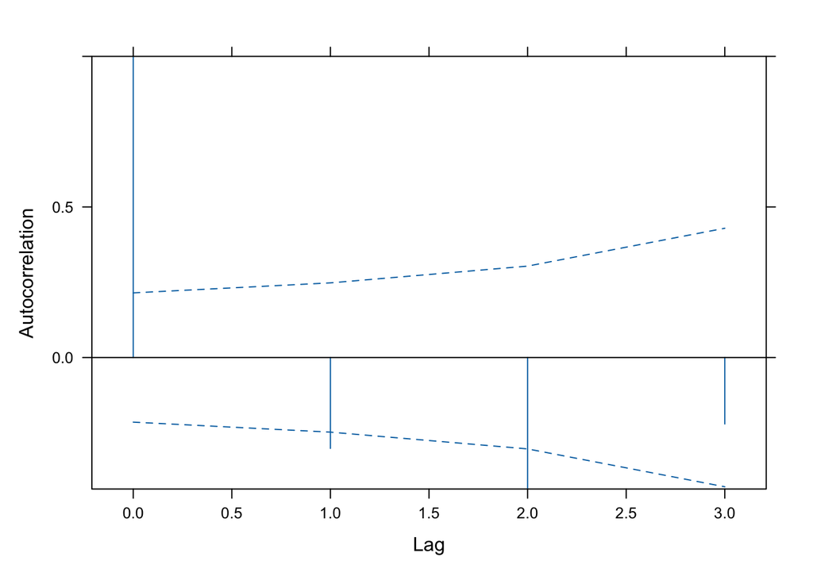

```r
ACF(mod1_default, resType = "n") %>%
  plot(alpha = 0.01)
```

# 8 Model 2 - Compound Symmetry

```r
mod2_cs <- lme(yield_kgha ~ krate_kgha*nrate_kgha*fdap,
                    random = ~ 1| block/krate_kgha/nrate_kgha,
                    correlation = corCompSymm(form = ~dap),
                    data = rm_rcbd_df
                    )

mod2_cs
```

```
Linear mixed-effects model fit by REML
  Data: rm_rcbd_df
  Log-restricted-likelihood: -627.5418
  Fixed: yield_kgha ~ krate_kgha * nrate_kgha * fdap
                  (Intercept)                   krate_kgha1
                5233.48611111                 -125.27777778
                  krate_kgha2                   nrate_kgha1
                 -27.77777778                  286.53472222
                  nrate_kgha2                         fdap1
                -189.65277778                 -412.15277778
                        fdap2                         fdap3
                 -12.76388889                  186.76388889
      krate_kgha1:nrate_kgha1       krate_kgha2:nrate_kgha1
                 165.06944444                 -873.86805556
      krate_kgha1:nrate_kgha2       krate_kgha2:nrate_kgha2
                -566.24305556                  469.00694444
            krate_kgha1:fdap1             krate_kgha2:fdap1
                   0.36111111                    1.36111111
            krate_kgha1:fdap2             krate_kgha2:fdap2
                  -3.44444444                   -1.11111111
            krate_kgha1:fdap3             krate_kgha2:fdap3
                  -0.88888889                    1.61111111
            nrate_kgha1:fdap1             nrate_kgha2:fdap1
                  -3.61805556                    2.40277778
            nrate_kgha1:fdap2             nrate_kgha2:fdap2
                   1.65972222                   -0.06944444
            nrate_kgha1:fdap3             nrate_kgha2:fdap3
                   3.21527778                   -3.93055556
krate_kgha1:nrate_kgha1:fdap1 krate_kgha2:nrate_kgha1:fdap1
                  -0.40277778                    6.28472222
krate_kgha1:nrate_kgha2:fdap1 krate_kgha2:nrate_kgha2:fdap1
                   3.07638889                   -2.42361111
krate_kgha1:nrate_kgha1:fdap2 krate_kgha2:nrate_kgha1:fdap2
                   3.48611111                  -14.15972222
krate_kgha1:nrate_kgha2:fdap2 krate_kgha2:nrate_kgha2:fdap2
                  -7.53472222                    7.38194444
krate_kgha1:nrate_kgha1:fdap3 krate_kgha2:nrate_kgha1:fdap3
                   1.59722222                   -2.21527778
krate_kgha1:nrate_kgha2:fdap3 krate_kgha2:nrate_kgha2:fdap3
                  -1.25694444                    2.49305556
```

[output cut: 10 more lines]

```
 Formula: ~1 | nrate_kgha %in% krate_kgha %in% block
        (Intercept) Residual
StdDev:    581.9141 15.47071

Correlation Structure: Compound symmetry
 Formula: ~dap | block/krate_kgha/nrate_kgha
 Parameter estimate(s):
      Rho
0.1122944
Number of Observations: 144
Number of Groups:
                                block                 krate_kgha %in% block
                                    4                                    12
nrate_kgha %in% krate_kgha %in% block
                                   36
```

## 8.1 empirical autocorrelation function

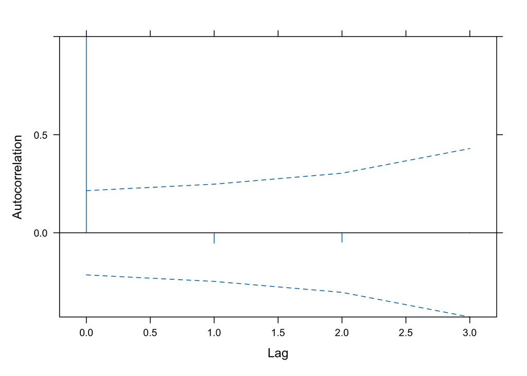

```r
ACF(mod2_cs, resType = "n") %>%
  plot(alpha = 0.01)
```

# 9 Model 3 - General

```r
mod3_gen <- lme(
  yield_kgha ~ krate_kgha*nrate_kgha*fdap,
  random = ~ 1|block/krate_kgha/nrate_kgha,
  correlation = corSymm(),
  data = rm_rcbd_df)

mod3_gen
```

```
Linear mixed-effects model fit by REML
  Data: rm_rcbd_df
  Log-restricted-likelihood: -620.6773
  Fixed: yield_kgha ~ krate_kgha * nrate_kgha * fdap
                  (Intercept)                   krate_kgha1
                5233.48611111                 -125.27777778
                  krate_kgha2                   nrate_kgha1
                 -27.77777778                  286.53472222
                  nrate_kgha2                         fdap1
                -189.65277778                 -412.15277778
                        fdap2                         fdap3
                 -12.76388889                  186.76388889
      krate_kgha1:nrate_kgha1       krate_kgha2:nrate_kgha1
                 165.06944444                 -873.86805556
      krate_kgha1:nrate_kgha2       krate_kgha2:nrate_kgha2
                -566.24305556                  469.00694444
            krate_kgha1:fdap1             krate_kgha2:fdap1
                   0.36111111                    1.36111111
            krate_kgha1:fdap2             krate_kgha2:fdap2
                  -3.44444444                   -1.11111111
            krate_kgha1:fdap3             krate_kgha2:fdap3
                  -0.88888889                    1.61111111
            nrate_kgha1:fdap1             nrate_kgha2:fdap1
                  -3.61805556                    2.40277778
            nrate_kgha1:fdap2             nrate_kgha2:fdap2
                   1.65972222                   -0.06944444
            nrate_kgha1:fdap3             nrate_kgha2:fdap3
                   3.21527778                   -3.93055556
krate_kgha1:nrate_kgha1:fdap1 krate_kgha2:nrate_kgha1:fdap1
                  -0.40277778                    6.28472222
krate_kgha1:nrate_kgha2:fdap1 krate_kgha2:nrate_kgha2:fdap1
                   3.07638889                   -2.42361111
krate_kgha1:nrate_kgha1:fdap2 krate_kgha2:nrate_kgha1:fdap2
                   3.48611111                  -14.15972222
krate_kgha1:nrate_kgha2:fdap2 krate_kgha2:nrate_kgha2:fdap2
                  -7.53472222                    7.38194444
krate_kgha1:nrate_kgha1:fdap3 krate_kgha2:nrate_kgha1:fdap3
                   1.59722222                   -2.21527778
krate_kgha1:nrate_kgha2:fdap3 krate_kgha2:nrate_kgha2:fdap3
                  -1.25694444                    2.49305556
```

[output cut: 13 more lines]

```

Correlation Structure: General
 Formula: ~1 | block/krate_kgha/nrate_kgha
 Parameter estimate(s):
 Correlation:
  1      2      3
2  0.617
3 -0.050  0.304
4  0.187  0.203 -0.394
Number of Observations: 144
Number of Groups:
                                block                 krate_kgha %in% block
                                    4                                    12
nrate_kgha %in% krate_kgha %in% block
                                   36
```

## 9.1 empirical autocorrelation function

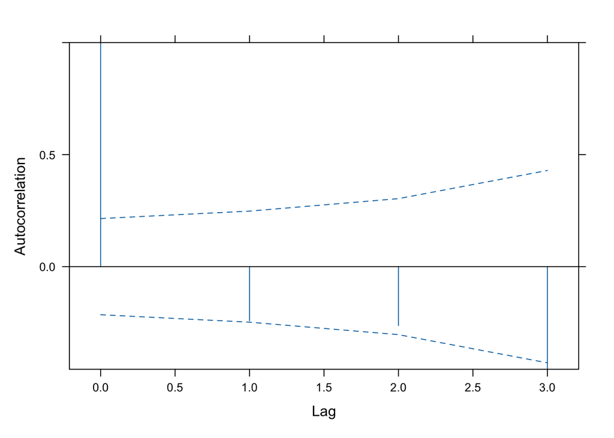

```r
ACF(mod3_gen, resType = "n") %>%
  plot(alpha = 0.01)
```

# 10 Model 4 - Autoregressive order 1 (AR1)

```r
mod4_ar1 <- lme(
  yield_kgha ~ krate_kgha*nrate_kgha*fdap,
  random = ~ 1|block/krate_kgha/nrate_kgha,
  correlation = corAR1(form = ~ dap),
  data = rm_rcbd_df)

mod4_ar1
```

```
Linear mixed-effects model fit by REML
  Data: rm_rcbd_df
  Log-restricted-likelihood: -627.5418
  Fixed: yield_kgha ~ krate_kgha * nrate_kgha * fdap
                  (Intercept)                   krate_kgha1
                5233.48611111                 -125.27777778
                  krate_kgha2                   nrate_kgha1
                 -27.77777778                  286.53472222
                  nrate_kgha2                         fdap1
                -189.65277778                 -412.15277778
                        fdap2                         fdap3
                 -12.76388889                  186.76388889
      krate_kgha1:nrate_kgha1       krate_kgha2:nrate_kgha1
                 165.06944444                 -873.86805556
      krate_kgha1:nrate_kgha2       krate_kgha2:nrate_kgha2
                -566.24305556                  469.00694444
            krate_kgha1:fdap1             krate_kgha2:fdap1
                   0.36111111                    1.36111111
            krate_kgha1:fdap2             krate_kgha2:fdap2
                  -3.44444444                   -1.11111111
            krate_kgha1:fdap3             krate_kgha2:fdap3
                  -0.88888889                    1.61111111
            nrate_kgha1:fdap1             nrate_kgha2:fdap1
                  -3.61805556                    2.40277778
            nrate_kgha1:fdap2             nrate_kgha2:fdap2
                   1.65972222                   -0.06944444
            nrate_kgha1:fdap3             nrate_kgha2:fdap3
                   3.21527778                   -3.93055556
krate_kgha1:nrate_kgha1:fdap1 krate_kgha2:nrate_kgha1:fdap1
                  -0.40277778                    6.28472222
krate_kgha1:nrate_kgha2:fdap1 krate_kgha2:nrate_kgha2:fdap1
                   3.07638889                   -2.42361111
krate_kgha1:nrate_kgha1:fdap2 krate_kgha2:nrate_kgha1:fdap2
                   3.48611111                  -14.15972222
krate_kgha1:nrate_kgha2:fdap2 krate_kgha2:nrate_kgha2:fdap2
                  -7.53472222                    7.38194444
krate_kgha1:nrate_kgha1:fdap3 krate_kgha2:nrate_kgha1:fdap3
                   1.59722222                   -2.21527778
krate_kgha1:nrate_kgha2:fdap3 krate_kgha2:nrate_kgha2:fdap3
                  -1.25694444                    2.49305556
```

[output cut: 10 more lines]

```
 Formula: ~1 | nrate_kgha %in% krate_kgha %in% block
        (Intercept) Residual
StdDev:    581.9363 14.57621

Correlation Structure: ARMA(1,0)
 Formula: ~dap | block/krate_kgha/nrate_kgha
 Parameter estimate(s):
Phi1
   0
Number of Observations: 144
Number of Groups:
                                block                 krate_kgha %in% block
                                    4                                    12
nrate_kgha %in% krate_kgha %in% block
                                   36
```

## 10.1 empirical autocorrelation function

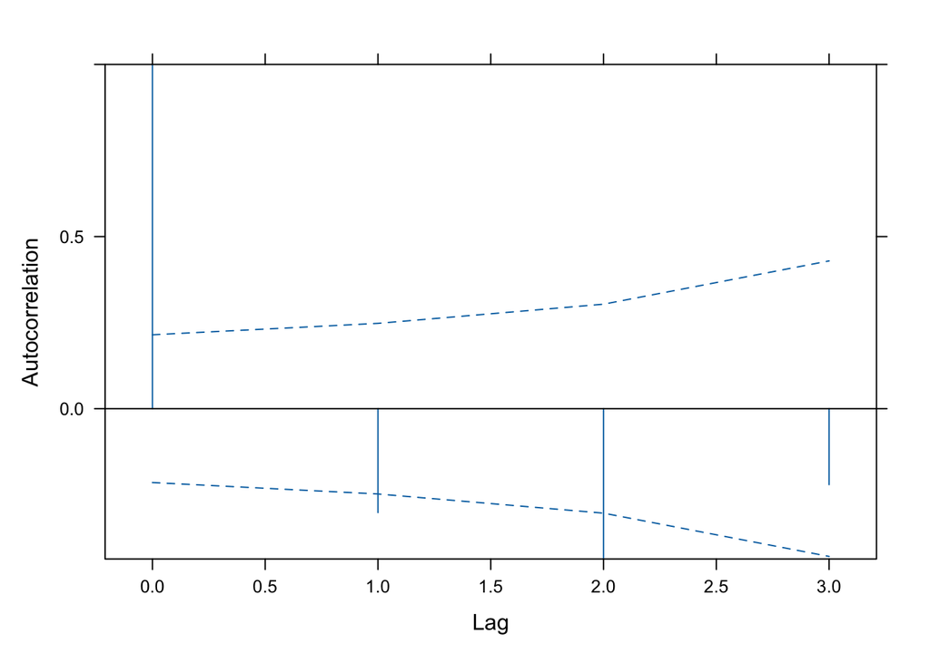

```r
ACF(mod4_ar1, resType = "n") %>%
  plot(alpha = 0.01)
```

# 11 Model 5 - Autoregressive order moving average (ARMA11)

```r
mod5_arma11 <- lme(
  yield_kgha ~ krate_kgha*nrate_kgha*fdap,
  random = ~ 1|block/krate_kgha/nrate_kgha,
  correlation = corARMA(p = 1, q = 1),
  data = rm_rcbd_df)

mod5_arma11
```

```
Linear mixed-effects model fit by REML
  Data: rm_rcbd_df
  Log-restricted-likelihood: -627.2962
  Fixed: yield_kgha ~ krate_kgha * nrate_kgha * fdap
                  (Intercept)                   krate_kgha1
                5233.48611111                 -125.27777778
                  krate_kgha2                   nrate_kgha1
                 -27.77777778                  286.53472222
                  nrate_kgha2                         fdap1
                -189.65277778                 -412.15277778
                        fdap2                         fdap3
                 -12.76388889                  186.76388889
      krate_kgha1:nrate_kgha1       krate_kgha2:nrate_kgha1
                 165.06944444                 -873.86805556
      krate_kgha1:nrate_kgha2       krate_kgha2:nrate_kgha2
                -566.24305556                  469.00694444
            krate_kgha1:fdap1             krate_kgha2:fdap1
                   0.36111111                    1.36111111
            krate_kgha1:fdap2             krate_kgha2:fdap2
                  -3.44444444                   -1.11111111
            krate_kgha1:fdap3             krate_kgha2:fdap3
                  -0.88888889                    1.61111111
            nrate_kgha1:fdap1             nrate_kgha2:fdap1
                  -3.61805556                    2.40277778
            nrate_kgha1:fdap2             nrate_kgha2:fdap2
                   1.65972222                   -0.06944444
            nrate_kgha1:fdap3             nrate_kgha2:fdap3
                   3.21527778                   -3.93055556
krate_kgha1:nrate_kgha1:fdap1 krate_kgha2:nrate_kgha1:fdap1
                  -0.40277778                    6.28472222
krate_kgha1:nrate_kgha2:fdap1 krate_kgha2:nrate_kgha2:fdap1
                   3.07638889                   -2.42361111
krate_kgha1:nrate_kgha1:fdap2 krate_kgha2:nrate_kgha1:fdap2
                   3.48611111                  -14.15972222
krate_kgha1:nrate_kgha2:fdap2 krate_kgha2:nrate_kgha2:fdap2
                  -7.53472222                    7.38194444
krate_kgha1:nrate_kgha1:fdap3 krate_kgha2:nrate_kgha1:fdap3
                   1.59722222                   -2.21527778
krate_kgha1:nrate_kgha2:fdap3 krate_kgha2:nrate_kgha2:fdap3
                  -1.25694444                    2.49305556
```

[output cut: 10 more lines]

```
 Formula: ~1 | nrate_kgha %in% krate_kgha %in% block
        (Intercept) Residual
StdDev:    581.9045 14.72326

Correlation Structure: ARMA(1,1)
 Formula: ~1 | block/krate_kgha/nrate_kgha
 Parameter estimate(s):
      Phi1     Theta1
-0.8805064  0.9997444
Number of Observations: 144
Number of Groups:
                                block                 krate_kgha %in% block
                                    4                                    12
nrate_kgha %in% krate_kgha %in% block
                                   36
```

## 11.1 empirical autocorrelation function

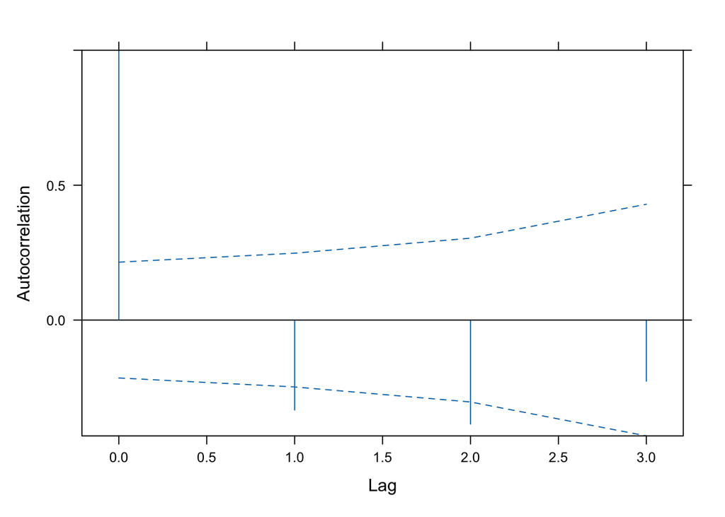

```r
ACF(mod5_arma11, resType = "n") %>%
  plot(alpha = 0.01)
```

# 12 Model 6 - Exponential

```r
mod6_exp <- lme(
  yield_kgha ~ krate_kgha*nrate_kgha*fdap,
  random = ~ 1|block/krate_kgha/nrate_kgha,
  correlation = corExp(form = ~dap),
  data = rm_rcbd_df)

mod6_exp
```

```
Linear mixed-effects model fit by REML
  Data: rm_rcbd_df
  Log-restricted-likelihood: -627.4828
  Fixed: yield_kgha ~ krate_kgha * nrate_kgha * fdap
                  (Intercept)                   krate_kgha1
                5233.48611111                 -125.27777778
                  krate_kgha2                   nrate_kgha1
                 -27.77777778                  286.53472222
                  nrate_kgha2                         fdap1
                -189.65277778                 -412.15277778
                        fdap2                         fdap3
                 -12.76388889                  186.76388889
      krate_kgha1:nrate_kgha1       krate_kgha2:nrate_kgha1
                 165.06944444                 -873.86805556
      krate_kgha1:nrate_kgha2       krate_kgha2:nrate_kgha2
                -566.24305556                  469.00694444
            krate_kgha1:fdap1             krate_kgha2:fdap1
                   0.36111111                    1.36111111
            krate_kgha1:fdap2             krate_kgha2:fdap2
                  -3.44444444                   -1.11111111
            krate_kgha1:fdap3             krate_kgha2:fdap3
                  -0.88888889                    1.61111111
            nrate_kgha1:fdap1             nrate_kgha2:fdap1
                  -3.61805556                    2.40277778
            nrate_kgha1:fdap2             nrate_kgha2:fdap2
                   1.65972222                   -0.06944444
            nrate_kgha1:fdap3             nrate_kgha2:fdap3
                   3.21527778                   -3.93055556
krate_kgha1:nrate_kgha1:fdap1 krate_kgha2:nrate_kgha1:fdap1
                  -0.40277778                    6.28472222
krate_kgha1:nrate_kgha2:fdap1 krate_kgha2:nrate_kgha2:fdap1
                   3.07638889                   -2.42361111
krate_kgha1:nrate_kgha1:fdap2 krate_kgha2:nrate_kgha1:fdap2
                   3.48611111                  -14.15972222
krate_kgha1:nrate_kgha2:fdap2 krate_kgha2:nrate_kgha2:fdap2
                  -7.53472222                    7.38194444
krate_kgha1:nrate_kgha1:fdap3 krate_kgha2:nrate_kgha1:fdap3
                   1.59722222                   -2.21527778
krate_kgha1:nrate_kgha2:fdap3 krate_kgha2:nrate_kgha2:fdap3
                  -1.25694444                    2.49305556
```

[output cut: 10 more lines]

```
 Formula: ~1 | nrate_kgha %in% krate_kgha %in% block
        (Intercept) Residual
StdDev:    581.7862 14.82263

Correlation Structure: Exponential spatial correlation
 Formula: ~dap | block/krate_kgha/nrate_kgha
 Parameter estimate(s):
   range
3.612324
Number of Observations: 144
Number of Groups:
                                block                 krate_kgha %in% block
                                    4                                    12
nrate_kgha %in% krate_kgha %in% block
                                   36
```

## 12.1 empirical autocorrelation function

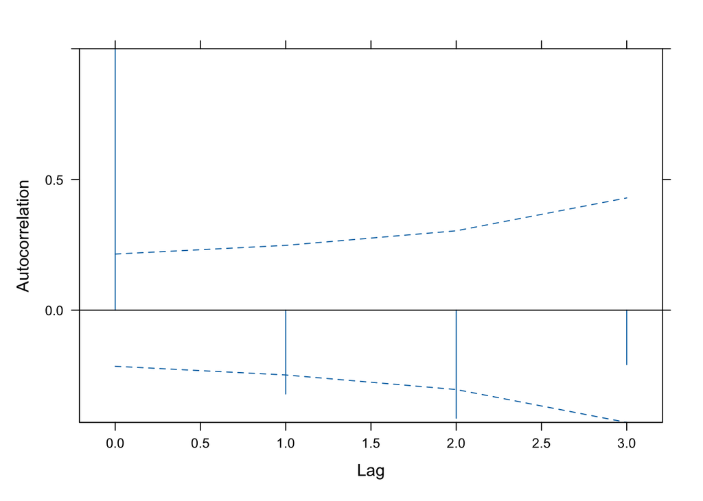

```r
ACF(mod6_exp, resType = "n") %>%
  plot(alpha = 0.01)
```

# 13 Model 7 - Gaussian

```r
mod7_gaus <- lme(
  yield_kgha ~ krate_kgha*nrate_kgha*fdap,
  random = ~ 1|block/krate_kgha/nrate_kgha,
  correlation = corGaus(form = ~dap),
  data = rm_rcbd_df)

mod7_gaus
```

```
Linear mixed-effects model fit by REML
  Data: rm_rcbd_df
  Log-restricted-likelihood: -627.4704
  Fixed: yield_kgha ~ krate_kgha * nrate_kgha * fdap
                  (Intercept)                   krate_kgha1
                5233.48611111                 -125.27777778
                  krate_kgha2                   nrate_kgha1
                 -27.77777778                  286.53472222
                  nrate_kgha2                         fdap1
                -189.65277778                 -412.15277778
                        fdap2                         fdap3
                 -12.76388889                  186.76388889
      krate_kgha1:nrate_kgha1       krate_kgha2:nrate_kgha1
                 165.06944444                 -873.86805556
      krate_kgha1:nrate_kgha2       krate_kgha2:nrate_kgha2
                -566.24305556                  469.00694444
            krate_kgha1:fdap1             krate_kgha2:fdap1
                   0.36111111                    1.36111111
            krate_kgha1:fdap2             krate_kgha2:fdap2
                  -3.44444444                   -1.11111111
            krate_kgha1:fdap3             krate_kgha2:fdap3
                  -0.88888889                    1.61111111
            nrate_kgha1:fdap1             nrate_kgha2:fdap1
                  -3.61805556                    2.40277778
            nrate_kgha1:fdap2             nrate_kgha2:fdap2
                   1.65972222                   -0.06944444
            nrate_kgha1:fdap3             nrate_kgha2:fdap3
                   3.21527778                   -3.93055556
krate_kgha1:nrate_kgha1:fdap1 krate_kgha2:nrate_kgha1:fdap1
                  -0.40277778                    6.28472222
krate_kgha1:nrate_kgha2:fdap1 krate_kgha2:nrate_kgha2:fdap1
                   3.07638889                   -2.42361111
krate_kgha1:nrate_kgha1:fdap2 krate_kgha2:nrate_kgha1:fdap2
                   3.48611111                  -14.15972222
krate_kgha1:nrate_kgha2:fdap2 krate_kgha2:nrate_kgha2:fdap2
                  -7.53472222                    7.38194444
krate_kgha1:nrate_kgha1:fdap3 krate_kgha2:nrate_kgha1:fdap3
                   1.59722222                   -2.21527778
krate_kgha1:nrate_kgha2:fdap3 krate_kgha2:nrate_kgha2:fdap3
                  -1.25694444                    2.49305556
```

[output cut: 10 more lines]

```
 Formula: ~1 | nrate_kgha %in% krate_kgha %in% block
        (Intercept) Residual
StdDev:    581.7641 14.84948

Correlation Structure: Gaussian spatial correlation
 Formula: ~dap | block/krate_kgha/nrate_kgha
 Parameter estimate(s):
   range
6.158661
Number of Observations: 144
Number of Groups:
                                block                 krate_kgha %in% block
                                    4                                    12
nrate_kgha %in% krate_kgha %in% block
                                   36
```

## 13.1 empirical autocorrelation function

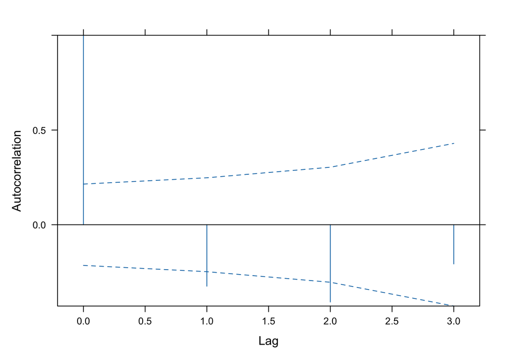

```r
ACF(mod7_gaus, resType = "n") %>%
  plot(alpha = 0.01)
```

# 14 Model 8 - Linear

```r
mod8_lin <- lme(
  yield_kgha ~ krate_kgha*nrate_kgha*fdap,
  random = ~ 1|block/krate_kgha/nrate_kgha,
  correlation = corLin(form = ~dap),
  data = rm_rcbd_df)

mod8_lin
```

```
Linear mixed-effects model fit by REML
  Data: rm_rcbd_df
  Log-restricted-likelihood: -627.4704
  Fixed: yield_kgha ~ krate_kgha * nrate_kgha * fdap
                  (Intercept)                   krate_kgha1
                5233.48611111                 -125.27777778
                  krate_kgha2                   nrate_kgha1
                 -27.77777778                  286.53472222
                  nrate_kgha2                         fdap1
                -189.65277778                 -412.15277778
                        fdap2                         fdap3
                 -12.76388889                  186.76388889
      krate_kgha1:nrate_kgha1       krate_kgha2:nrate_kgha1
                 165.06944444                 -873.86805556
      krate_kgha1:nrate_kgha2       krate_kgha2:nrate_kgha2
                -566.24305556                  469.00694444
            krate_kgha1:fdap1             krate_kgha2:fdap1
                   0.36111111                    1.36111111
            krate_kgha1:fdap2             krate_kgha2:fdap2
                  -3.44444444                   -1.11111111
            krate_kgha1:fdap3             krate_kgha2:fdap3
                  -0.88888889                    1.61111111
            nrate_kgha1:fdap1             nrate_kgha2:fdap1
                  -3.61805556                    2.40277778
            nrate_kgha1:fdap2             nrate_kgha2:fdap2
                   1.65972222                   -0.06944444
            nrate_kgha1:fdap3             nrate_kgha2:fdap3
                   3.21527778                   -3.93055556
krate_kgha1:nrate_kgha1:fdap1 krate_kgha2:nrate_kgha1:fdap1
                  -0.40277778                    6.28472222
krate_kgha1:nrate_kgha2:fdap1 krate_kgha2:nrate_kgha2:fdap1
                   3.07638889                   -2.42361111
krate_kgha1:nrate_kgha1:fdap2 krate_kgha2:nrate_kgha1:fdap2
                   3.48611111                  -14.15972222
krate_kgha1:nrate_kgha2:fdap2 krate_kgha2:nrate_kgha2:fdap2
                  -7.53472222                    7.38194444
krate_kgha1:nrate_kgha1:fdap3 krate_kgha2:nrate_kgha1:fdap3
                   1.59722222                   -2.21527778
krate_kgha1:nrate_kgha2:fdap3 krate_kgha2:nrate_kgha2:fdap3
                  -1.25694444                    2.49305556
```

[output cut: 10 more lines]

```
 Formula: ~1 | nrate_kgha %in% krate_kgha %in% block
        (Intercept) Residual
StdDev:    581.7643 14.84992

Correlation Structure: Linear spatial correlation
 Formula: ~dap | block/krate_kgha/nrate_kgha
 Parameter estimate(s):
   range
10.77271
Number of Observations: 144
Number of Groups:
                                block                 krate_kgha %in% block
                                    4                                    12
nrate_kgha %in% krate_kgha %in% block
                                   36
```

## 14.1 empirical autocorrelation function

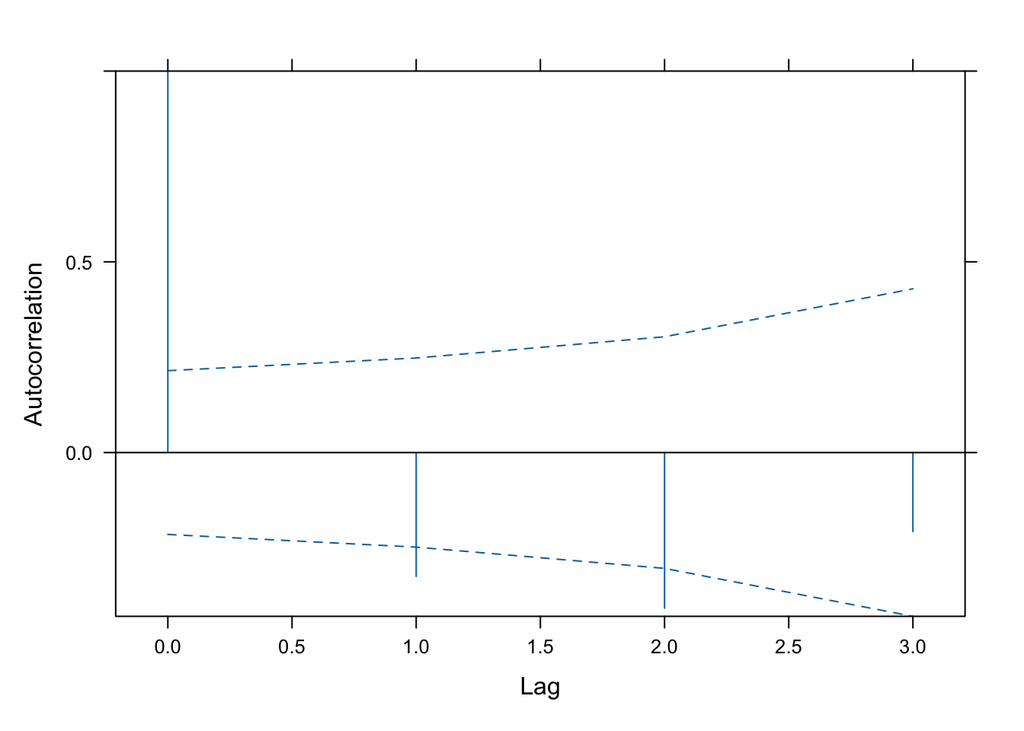

```r
ACF(mod8_lin, resType = "n") %>%
  plot(alpha = 0.01)
```

# 15 Model 9 - Rational Quadratic

```r
mod9_rq <- lme(
  yield_kgha ~ krate_kgha*nrate_kgha*fdap,
  random = ~ 1|block/krate_kgha/nrate_kgha,
  correlation = corRatio(form = ~dap),
  data = rm_rcbd_df)

mod9_rq
```

```
Linear mixed-effects model fit by REML
  Data: rm_rcbd_df
  Log-restricted-likelihood: -627.5039
  Fixed: yield_kgha ~ krate_kgha * nrate_kgha * fdap
                  (Intercept)                   krate_kgha1
                5233.48611111                 -125.27777778
                  krate_kgha2                   nrate_kgha1
                 -27.77777778                  286.53472222
                  nrate_kgha2                         fdap1
                -189.65277778                 -412.15277778
                        fdap2                         fdap3
                 -12.76388889                  186.76388889
      krate_kgha1:nrate_kgha1       krate_kgha2:nrate_kgha1
                 165.06944444                 -873.86805556
      krate_kgha1:nrate_kgha2       krate_kgha2:nrate_kgha2
                -566.24305556                  469.00694444
            krate_kgha1:fdap1             krate_kgha2:fdap1
                   0.36111111                    1.36111111
            krate_kgha1:fdap2             krate_kgha2:fdap2
                  -3.44444444                   -1.11111111
            krate_kgha1:fdap3             krate_kgha2:fdap3
                  -0.88888889                    1.61111111
            nrate_kgha1:fdap1             nrate_kgha2:fdap1
                  -3.61805556                    2.40277778
            nrate_kgha1:fdap2             nrate_kgha2:fdap2
                   1.65972222                   -0.06944444
            nrate_kgha1:fdap3             nrate_kgha2:fdap3
                   3.21527778                   -3.93055556
krate_kgha1:nrate_kgha1:fdap1 krate_kgha2:nrate_kgha1:fdap1
                  -0.40277778                    6.28472222
krate_kgha1:nrate_kgha2:fdap1 krate_kgha2:nrate_kgha2:fdap1
                   3.07638889                   -2.42361111
krate_kgha1:nrate_kgha1:fdap2 krate_kgha2:nrate_kgha1:fdap2
                   3.48611111                  -14.15972222
krate_kgha1:nrate_kgha2:fdap2 krate_kgha2:nrate_kgha2:fdap2
                  -7.53472222                    7.38194444
krate_kgha1:nrate_kgha1:fdap3 krate_kgha2:nrate_kgha1:fdap3
                   1.59722222                   -2.21527778
krate_kgha1:nrate_kgha2:fdap3 krate_kgha2:nrate_kgha2:fdap3
                  -1.25694444                    2.49305556
```

[output cut: 10 more lines]

```
 Formula: ~1 | nrate_kgha %in% krate_kgha %in% block
        (Intercept) Residual
StdDev:    581.7922 14.88151

Correlation Structure: Rational quadratic spatial correlation
 Formula: ~dap | block/krate_kgha/nrate_kgha
 Parameter estimate(s):
   range
2.664787
Number of Observations: 144
Number of Groups:
                                block                 krate_kgha %in% block
                                    4                                    12
nrate_kgha %in% krate_kgha %in% block
                                   36
```

## 15.1 empirical autocorrelation function

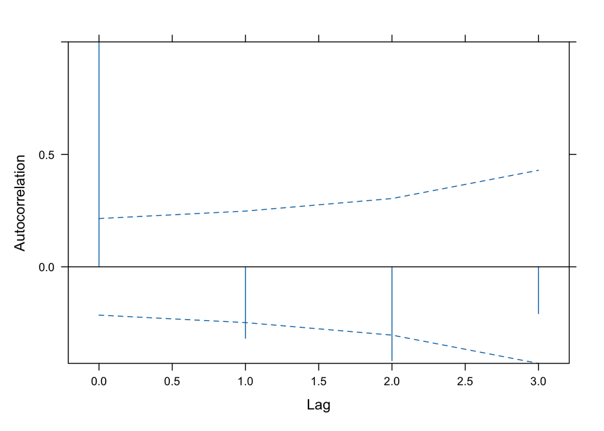

```r
ACF(mod9_rq, resType = "n") %>%
  plot(alpha = 0.01)
```

# 16 Model 10 - Spherical

```r
mod10_sph <- lme(
  yield_kgha ~ krate_kgha*nrate_kgha*fdap,
  random = ~ 1|block/krate_kgha/nrate_kgha,
  correlation = corSpher(form = ~dap),
  data = rm_rcbd_df)

mod10_sph
```

```
Linear mixed-effects model fit by REML
  Data: rm_rcbd_df
  Log-restricted-likelihood: -627.4704
  Fixed: yield_kgha ~ krate_kgha * nrate_kgha * fdap
                  (Intercept)                   krate_kgha1
                5233.48611111                 -125.27777778
                  krate_kgha2                   nrate_kgha1
                 -27.77777778                  286.53472222
                  nrate_kgha2                         fdap1
                -189.65277778                 -412.15277778
                        fdap2                         fdap3
                 -12.76388889                  186.76388889
      krate_kgha1:nrate_kgha1       krate_kgha2:nrate_kgha1
                 165.06944444                 -873.86805556
      krate_kgha1:nrate_kgha2       krate_kgha2:nrate_kgha2
                -566.24305556                  469.00694444
            krate_kgha1:fdap1             krate_kgha2:fdap1
                   0.36111111                    1.36111111
            krate_kgha1:fdap2             krate_kgha2:fdap2
                  -3.44444444                   -1.11111111
            krate_kgha1:fdap3             krate_kgha2:fdap3
                  -0.88888889                    1.61111111
            nrate_kgha1:fdap1             nrate_kgha2:fdap1
                  -3.61805556                    2.40277778
            nrate_kgha1:fdap2             nrate_kgha2:fdap2
                   1.65972222                   -0.06944444
            nrate_kgha1:fdap3             nrate_kgha2:fdap3
                   3.21527778                   -3.93055556
krate_kgha1:nrate_kgha1:fdap1 krate_kgha2:nrate_kgha1:fdap1
                  -0.40277778                    6.28472222
krate_kgha1:nrate_kgha2:fdap1 krate_kgha2:nrate_kgha2:fdap1
                   3.07638889                   -2.42361111
krate_kgha1:nrate_kgha1:fdap2 krate_kgha2:nrate_kgha1:fdap2
                   3.48611111                  -14.15972222
krate_kgha1:nrate_kgha2:fdap2 krate_kgha2:nrate_kgha2:fdap2
                  -7.53472222                    7.38194444
krate_kgha1:nrate_kgha1:fdap3 krate_kgha2:nrate_kgha1:fdap3
                   1.59722222                   -2.21527778
krate_kgha1:nrate_kgha2:fdap3 krate_kgha2:nrate_kgha2:fdap3
                  -1.25694444                    2.49305556
```

[output cut: 10 more lines]

```
 Formula: ~1 | nrate_kgha %in% krate_kgha %in% block
        (Intercept) Residual
StdDev:    581.7644 14.84992

Correlation Structure: Spherical spatial correlation
 Formula: ~dap | block/krate_kgha/nrate_kgha
 Parameter estimate(s):
   range
12.94445
Number of Observations: 144
Number of Groups:
                                block                 krate_kgha %in% block
                                    4                                    12
nrate_kgha %in% krate_kgha %in% block
                                   36
```

## 16.1 empirical autocorrelation function

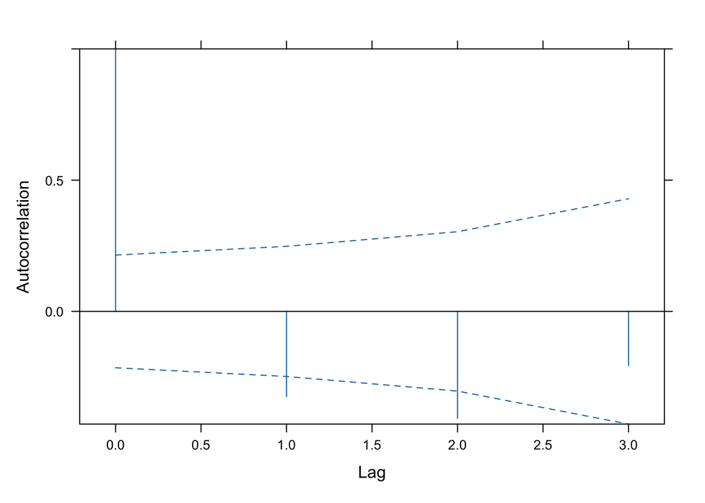

```r
ACF(mod10_sph, resType = "n") %>%
  plot(alpha = 0.01)
```

# 17 Final model comparison and selection

```r
anova(mod1_default,
      mod2_cs, mod3_gen, mod4_ar1, mod5_arma11,
      mod6_exp, mod7_gaus, mod8_lin, mod9_rq, mod10_sph) %>%
  as.data.frame() %>%
  rownames_to_column(var = "modelname") %>%
  janitor::clean_names() %>%
  dplyr::select(modelname, model, df, aic, bic) %>%
  arrange(bic)
```

```
      modelname model df      aic      bic
1  mod1_default     1 40 1335.084 1442.369
2     mod10_sph    10 41 1336.941 1446.908
3      mod8_lin     8 41 1336.941 1446.908
4     mod7_gaus     7 41 1336.941 1446.908
5      mod6_exp     6 41 1336.966 1446.933
6       mod9_rq     9 41 1337.008 1446.975
7      mod4_ar1     4 41 1337.084 1447.051
8       mod2_cs     2 41 1337.084 1447.051
9   mod5_arma11     5 42 1338.592 1451.242
10     mod3_gen     3 46 1333.355 1456.733
```

## 17.1 Q1: Include here the residual assessment of the default model. Include each plot and its interpretation. How do these residuals from the default model visually compare to those from the general model?

The residuals graphs look similar and both are complaint with the residual assumptions. Each explanation are after each plot.

```r
library(broom.mixed)
mod1_default_resid <- augment(mod1_default) %>%
  mutate(.stdresid=resid(mod1_default, type="pearson", scaled=T))

mod1_default_resid
```

```
# A tibble: 144 × 14
   trt   block nrate_kgha krate_kgha trtname wplot splot yield_kgha   dap fdap
   <fct> <fct> <fct>      <fct>      <fct>   <fct> <fct>      <dbl> <dbl> <fct>
 1 1     1     0          0          0+0     101   101-1       5488   120 120
 2 1     1     0          0          0+0     101   101-1       5898   130 130
 3 1     1     0          0          0+0     101   101-1       6133   140 140
 4 1     1     0          0          0+0     101   101-1       6151   150 150
 5 2     1     0          30         0+30    102   102-1       4448   120 120
 6 2     1     0          30         0+30    102   102-1       4842   130 130
 7 2     1     0          30         0+30    102   102-1       5057   140 140
 8 2     1     0          30         0+30    102   102-1       5094   150 150
 9 3     1     0          60         0+60    103   103-1       7445   120 120
10 3     1     0          60         0+60    103   103-1       7901   130 130
# ℹ 134 more rows
# ℹ 4 more variables: .fitted <dbl>, .resid <dbl>, .fixed <dbl>,
#   .stdresid <dbl>
```

### 17.1.1 Block random effects are iid ~ N(0,var_a)

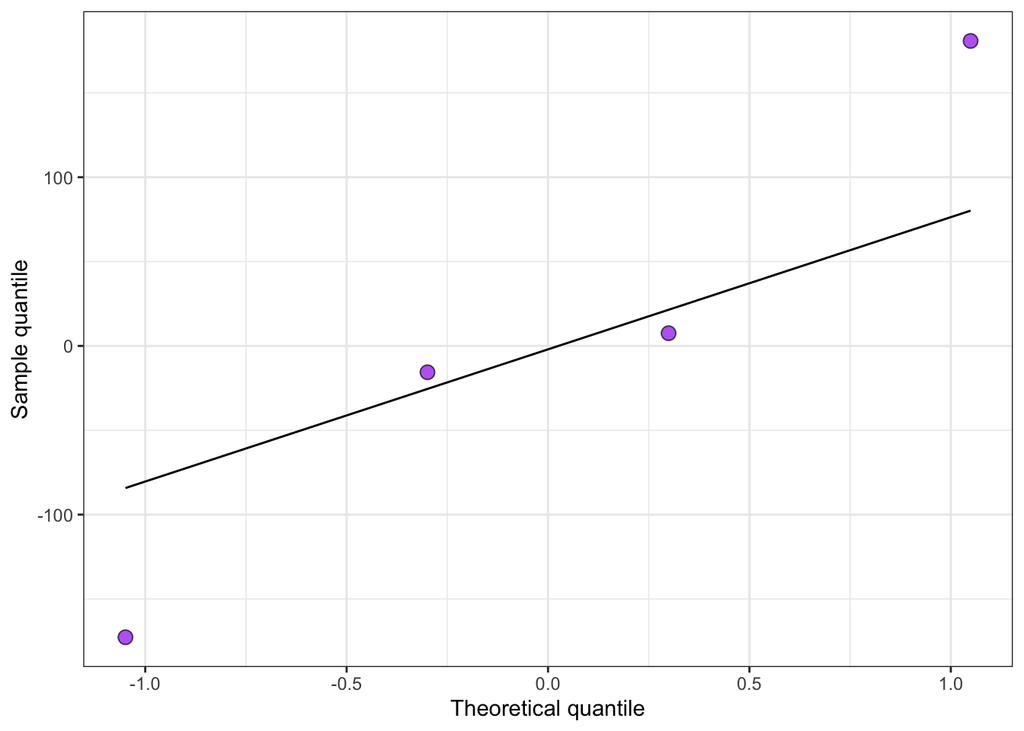

```r
ranef(mod1_default)[[1]] %>%
  ggplot(aes(sample=`(Intercept)`))+
  stat_qq(  shape = 21,
            fill = "purple",
            size = 3,
            alpha = .7
  )+
  stat_qq_line()+
  labs(x = "Theoretical quantile",
       y = "Sample quantile")+
  theme_bw()
```

We have 4 points corresponding to each of the blocks, they look good meaning there is not a big distance of the points from the line.

### 17.1.2 Block:krate random effects are iid ~ N(0,var_b)

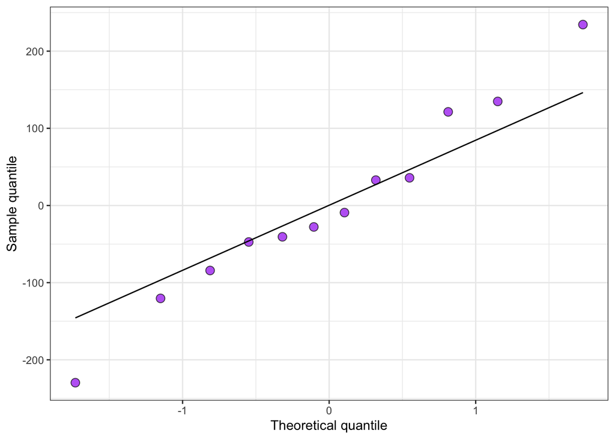

```r
ranef(mod1_default)[[2]] %>%
  ggplot(aes(sample=`(Intercept)`))+
  stat_qq(  shape = 21,
            fill = "purple",
            size = 3,
            alpha = .7
  )+
  stat_qq_line()+
  labs(x = "Theoretical quantile",
       y = "Sample quantile")+
  theme_bw()
```

We have 12 observations corresponding of the 4 blocks with 3 potassium levels. It looks good, some deviation in the beggining and the end but not to worry.

### 17.1.3 Block:krate:nrate random effects are iid ~ N(0,var_c)

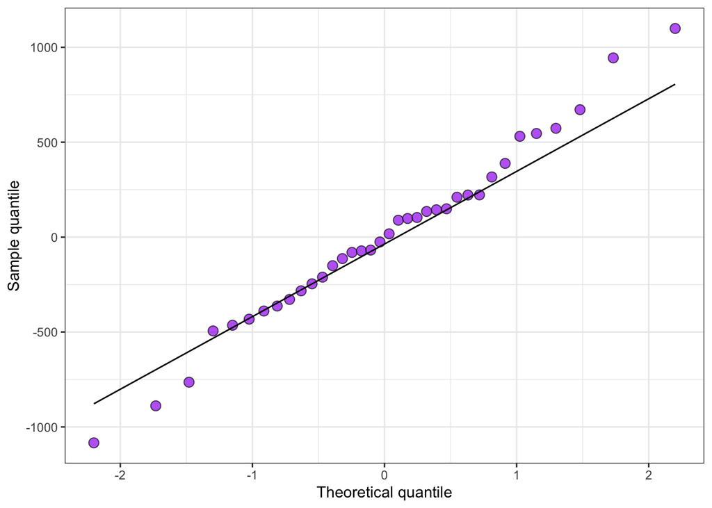

```r
ranef(mod1_default)[[3]] %>%
  ggplot(aes(sample=`(Intercept)`))+
  stat_qq(  shape = 21,
            fill = "purple",
            size = 3,
            alpha = .7
  )+
  stat_qq_line()+
  labs(x = "Theoretical quantile",
       y = "Sample quantile")+
  theme_bw()
```

This graph corresponds to the random effect component of nitrogen, inside potassium, inside block a little deviation but looks good overall.

### 17.1.4 Within-group errors are iid ~ N(0, var_e)

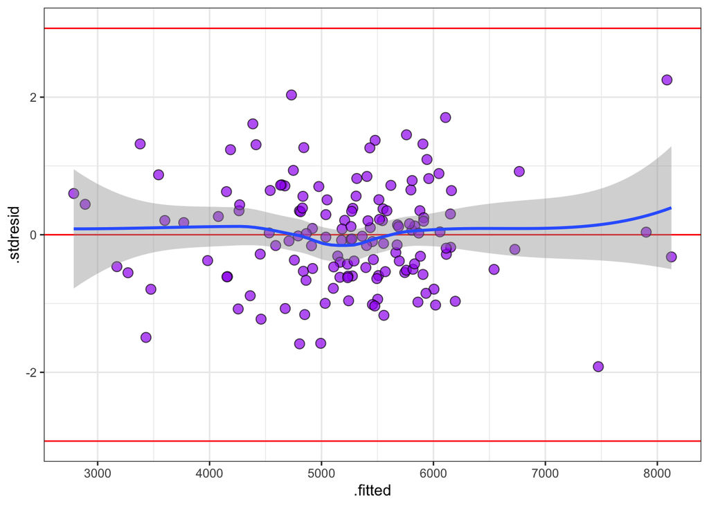

```r
ggplot(mod1_default_resid, aes(x=.fitted, y=.stdresid))+
  geom_hline(yintercept = 0, color="red")+
  geom_point(shape = 21,
             fill = "purple",
             size = 3,
             alpha = .7)+
  geom_smooth()+
  geom_hline(yintercept = c(-3,3), color = "red")+
  theme_bw()
```

We do not see a pattern, nothing is beyond 3 or -3 so no outlayers, it also does not seem that the variance is increasing as we increase the x axis. It seems independent, no outliers and the variance homogenous.

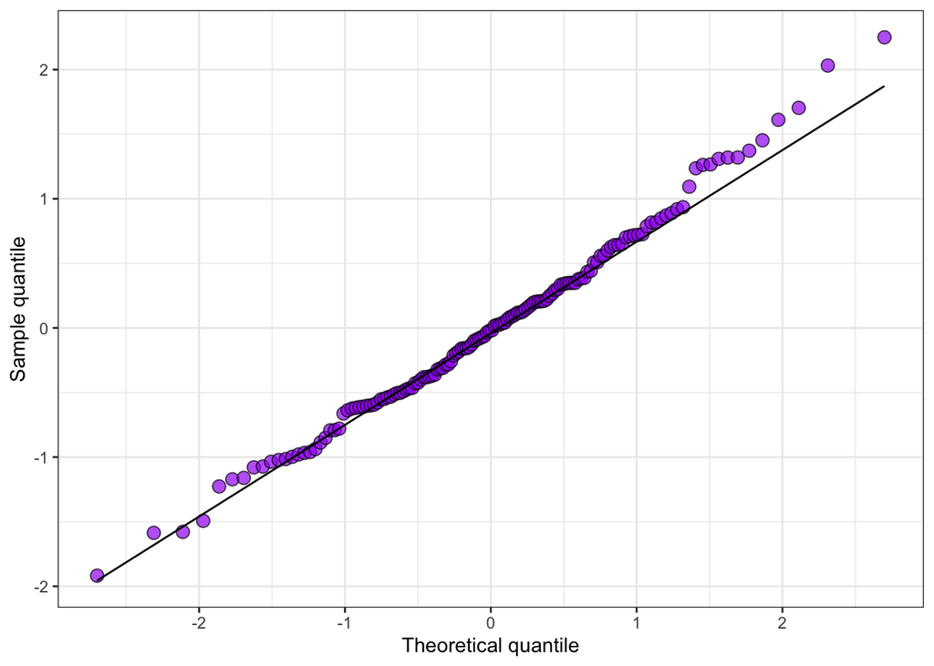

```r
ggplot(mod1_default_resid, aes(sample=.stdresid))+
  stat_qq(  shape = 21,
            fill = "purple",
            size = 3,
            alpha = .7
  )+
  stat_qq_line()+
  labs(x = "Theoretical quantile",
       y = "Sample quantile")+
  theme_bw()
```

Except for a few points on the upper tail, everything looks great. Overall looks good. So we can go with the ANOVA table

## 17.2 Q2: Include here the ANOVA table from the default model. How does it compare with the ANOVA table from the general model?

In the ANOVA table from the general model the most complex interaction while is not much in the default model. What is was significant in the default model was fdap and two way interaction of potassium with nitrogen.

# 18 Inference - default model

```r
Anova(mod1_default, type = 3)
```

```
Analysis of Deviance Table (Type III tests)

Response: yield_kgha
                                Chisq Df Pr(>Chisq)
(Intercept)                 1040.2040  1  < 2.2e-16 ***
krate_kgha                     0.9113  2    0.63404
nrate_kgha                     4.5157  2    0.10458
fdap                       44330.3557  3  < 2.2e-16 ***
krate_kgha:nrate_kgha         33.2786  4  1.047e-06 ***
krate_kgha:fdap                3.7507  6    0.71038
nrate_kgha:fdap                3.1727  6    0.78688
krate_kgha:nrate_kgha:fdap    19.8741 12    0.06951 .
---
Signif. codes:  0 '***' 0.001 '**' 0.01 '*' 0.05 '.' 0.1 ' ' 1
```

## 18.1 fdap

```r
rm_rcbd_cld_fdap <- emmeans(mod1_default, ~ fdap) %>%
  cld(reversed = T,
      Letters = letters,
      adjust = "none"
      ) %>%
  as.data.frame() %>%
  mutate(letter = trimws(.group))
```

```
NOTE: Results may be misleading due to involvement in interactions
```

```r
rm_rcbd_cld_fdap
```

```
  fdap   emmean       SE df lower.CL upper.CL .group letter
1  150 5471.639 162.2812  3 4955.188 5988.090   a         a
2  140 5420.250 162.2812  3 4903.799 5936.701    b        b
3  130 5220.722 162.2812  3 4704.271 5737.174     c       c
4  120 4821.333 162.2812  3 4304.882 5337.785      d      d
```

## 18.2 K x N interaction

```r
rm_rcbd_cld_interaction <- emmeans(mod1_default, ~krate_kgha*nrate_kgha) %>%
  cld(reversed = T,
      Letters = letters,
      adjust = "none"
      ) %>%
  as.data.frame() %>%
  mutate(letter = trimws(.group)) %>%
  mutate(trtname = paste0(nrate_kgha,"+",krate_kgha))
```

```
NOTE: Results may be misleading due to involvement in interactions
```

```r
rm_rcbd_cld_interaction
```

```
  krate_kgha nrate_kgha   emmean       SE df lower.CL upper.CL .group letter
4         60          0 6381.875 334.6113  3 5316.992 7446.758   a         a
9          0          0 5559.813 334.6113  3 4494.930 6624.695   abc     abc
2         30        200 5513.688 334.6113  3 4448.805 6578.570   ab       ab
6         30        100 5485.063 334.6113  3 4420.180 6549.945   ab       ab
7          0        200 5412.500 334.6113  3 4347.617 6477.383   abc     abc
5         60        100 5294.125 334.6113  3 4229.242 6359.008    bcd    bcd
8         30          0 4618.375 334.6113  3 3553.492 5683.258     cd     cd
1         60        200 4483.625 334.6113  3 3418.742 5548.508    bcd    bcd
3          0        100 4352.313 334.6113  3 3287.430 5417.195      d      d
  trtname
4    0+60
9     0+0
2  200+30
6  100+30
7   200+0
5  100+60
8    0+30
1  200+60
3   100+0
```

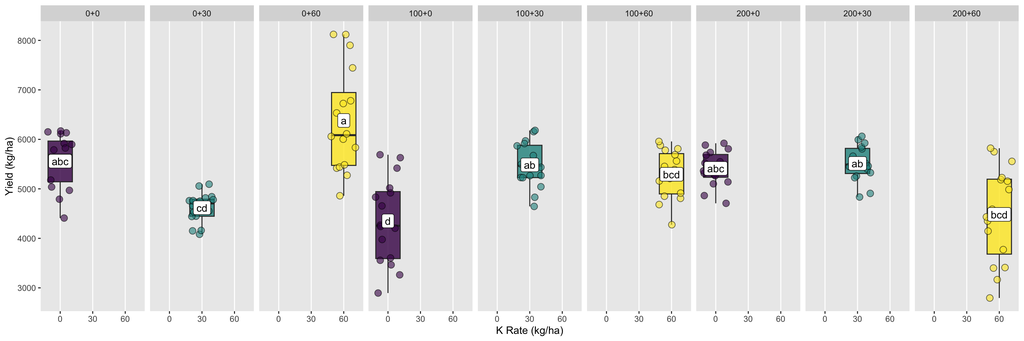

```r
ggplot(mapping = aes(fill = krate_kgha), y = yield_kgha, fill = factor(nrate_kgha))+
  # Raw data and boxplots
  geom_boxplot(data = rm_rcbd_df,
               aes(x = krate_kgha, y = yield_kgha),
               alpha = .8) +
  geom_jitter(data = rm_rcbd_df,
               aes(x = krate_kgha, y = yield_kgha),
              shape = 21,
              size = 3,
              alpha = .6) +
  # Adding letters
  geom_label(data = rm_rcbd_cld_interaction,
            aes(x = krate_kgha , y = emmean, label = letter),
            fill = "white") +
  labs(x = "K Rate (kg/ha)",
       y = "Yield (kg/ha)",
       fill = "N Rate (kg/ha)") +
  scale_fill_viridis_d() +
  facet_grid(.~trtname) +
  theme(panel.grid.major.y = element_blank(),
        panel.grid.minor.y = element_blank(),
        legend.position = "none")
```

# 19 Submitting your work

Once you have developed all the code and answers, make sure to Render this quarto file.

**Notes on rendering**:

- Make sure to render your work and inspect how the final html look like.
- If it does not look professional for whatever reason, then fix the issue, re-render it, recheck.
- Only send me your work once your html file looks professional.
  - **DO NOT** delete the file’s heading levels (# and ##). They set up the proper heading 1 and 2 levels, and I use them to guide my grading.
  - If a given chunk is also outputting warnings or messages, inhibit this behavior by changing the chunk options `message` and `warning` to `FALSE` (I’ll demo this in a moment).
  - If, after rendered, 2 lines of text are connected and you wish to “break line” between them, add 2 extra spaces after the first one (I’lld demo this in a moment).

After rendering, an .html file will be created on your `code` folder.

Rename this file to `Assignment-07-rm-LASTNAME.html`.

For ex., mine would be `Assignment-07-rm-Bastos.html`.

Submit your work by uploading the **html** file to **eLC Assigment #7 - Repeated measure** by Mar 25 11:59 pm.